```r
library(tidyverse)
library(tidymodels)
```

```r
library(ggplot2)
library(here)
options(scipen =999)
```

# Lab 6: Traditional Regression and Model Selection

## Part One: Data Exploration

The dataset we will study for this assignment contains information about health insurance costs for individuals with no dependents (children) in the United States. The information contained in the data is:

-Age of primary beneficiary

-Gender of primary beneficiary (only female, male recorded)

-Body mass index, providing an understanding of body, weights that are relatively high or low relative to height, objective index of body weight (kg / m ^ 2) using the ratio of height to weight, ideally 18.5 to 24.9 -Whether the beneficiary smokes

-The beneficiary’s residential area in the US, northeast, southeast, southwest, northwest.

-Individual medical costs billed by health insurance

You can find this data at: https://www.dropbox.com/s/bocjjyo1ehr5auz/insurance_costs_1.csv?dl=1

1.Read in the dataset, and display some summaries of the data.

```r
insurance <- read.csv(here("Data", "Insurance_Costs_1.csv"))
print(head(insurance))
```

```
##   age    sex    bmi smoker    region   charges
## 1  19 female 27.900    yes southwest 16884.924
## 2  33   male 22.705     no northwest 21984.471
## 3  32   male 28.880     no northwest  3866.855
## 4  31 female 25.740     no southeast  3756.622
## 5  60 female 25.840     no northwest 28923.137
## 6  25   male 26.220     no northeast  2721.321
```

```r
summary(insurance)
```

```
##       age            sex                 bmi           smoker
##  Min.   :18.00   Length:431         Min.   :15.96   Length:431
##  1st Qu.:22.00   Class :character   1st Qu.:26.36   Class :character
##  Median :34.00   Mode  :character   Median :30.59   Mode  :character
##  Mean   :37.96                      Mean   :30.77
##  3rd Qu.:55.00                      3rd Qu.:35.27
##  Max.   :64.00                      Max.   :49.06
##     region             charges
##  Length:431         Min.   : 1132
##  Class :character   1st Qu.: 2710
##  Mode  :character   Median : 9866
##                     Mean   :12297
##                     3rd Qu.:14511
##                     Max.   :55135
```

2.Fix any concerns you have about the data.

```r
insurance <- insurance %>%
  mutate(sex = factor(sex), smoker = factor(smoker), region = factor(region))
```

3.Make up to three plots comparing the response variable (charges) to one of the predictor variables. Briefly discuss each plot.

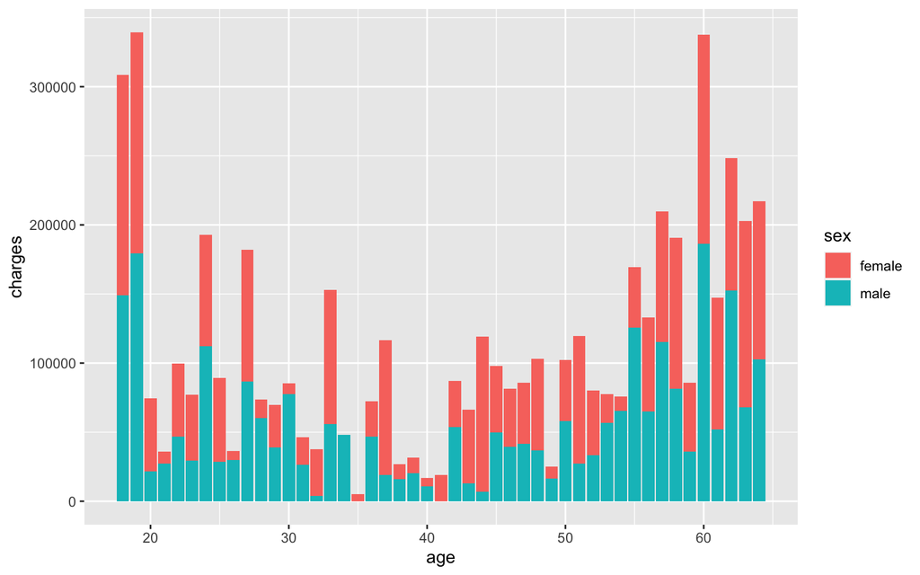

```r
insurance %>%
  ggplot(aes(x=age, y=charges, fill=sex))+
  geom_col()
```

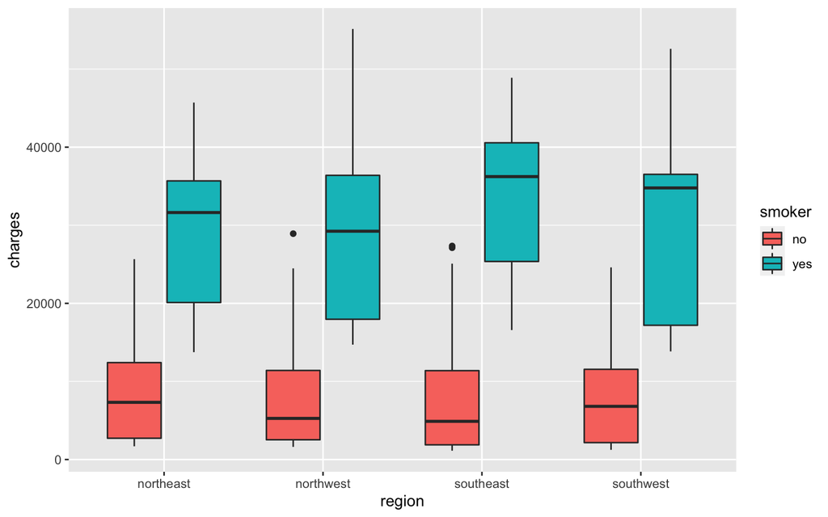

```r
insurance %>%
  ggplot(aes(x=region , y=charges, fill=smoker)) +
  geom_boxplot()
```

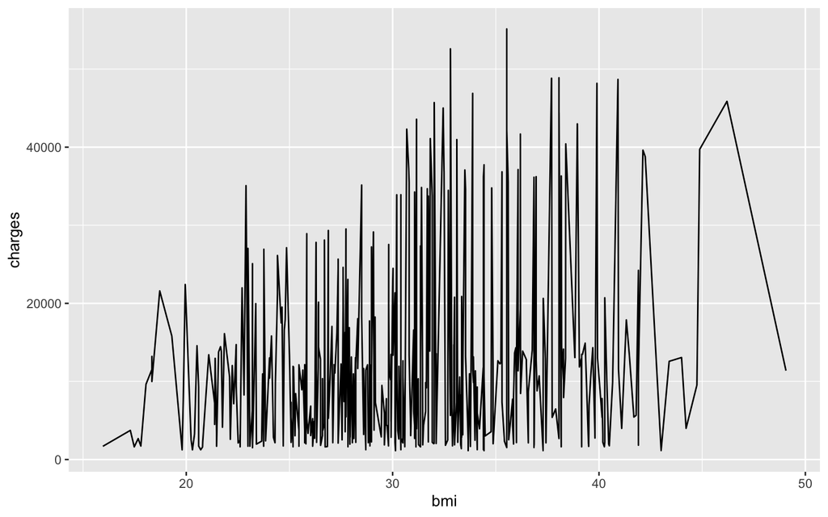

```r
insurance %>%
  ggplot(aes(x=bmi , y=charges)) +
  geom_line()
```

Column Plot: From the column plot it seems like the charges start high for low ages and increase as age increases with charges for females being slightly higher than males overall.

Box Plot: From the box plot it seems charges vary for regions slightly for non-smokers and more so for smokers with charges for smokers being higher in general, especially in the southeast.

Line Plot: From the line plot it seems like in general, charges increase as bmi increases, with charges being highest in the 30-40 bmi range.

## Part Two: Simple Linear Models

1.Construct a simple linear model to predict the insurance charges from the beneficiary’s age. Discuss the model fit, and interpret the coefficient estimates.

```r
model1 <- lm(charges~age, data=insurance)
summary(model1)
```

```
##
## Call:
## lm(formula = charges ~ age, data = insurance)
##
## Residuals:
##    Min     1Q Median     3Q    Max
##  -7458  -6490  -5628   4154  43973
##
## Coefficients:
##             Estimate Std. Error t value        Pr(>|t|)
## (Intercept)  3611.76    1374.39   2.628          0.0089 **
## age           228.80      33.25   6.880 0.0000000000212 ***
## ---
## Signif. codes:  0 '***' 0.001 '**' 0.01 '*' 0.05 '.' 0.1 ' ' 1
##
## Residual standard error: 11280 on 429 degrees of freedom
## Multiple R-squared:  0.09938,    Adjusted R-squared:  0.09728
## F-statistic: 47.34 on 1 and 429 DF,  p-value: 0.00000000002124
```

- An R squared values of 9.94% reveals that 9.94% of the variability observed in charges is explained by the model which is relatively low.
- The beta coefficient for age tells us that for a 1 year increase in age the charges increase by $228.80 on average holding everything else constant.

2.Make a model that also incorporates the variable sex. Report your results.

```r
model2 <- lm(charges~age*sex, data=insurance)
summary(model2)
```

```
##
## Call:
## lm(formula = charges ~ age * sex, data = insurance)
##
## Residuals:
##    Min     1Q Median     3Q    Max
##  -7901  -6520  -5419   4354  44350
##
## Coefficients:
##             Estimate Std. Error t value    Pr(>|t|)
## (Intercept)  2763.40    1899.33   1.455       0.146
## age           243.08      46.29   5.252 0.000000238 ***
## sexmale      1804.77    2757.32   0.655       0.513
## age:sexmale   -30.40      66.68  -0.456       0.649
## ---
## Signif. codes:  0 '***' 0.001 '**' 0.01 '*' 0.05 '.' 0.1 ' ' 1
##
## Residual standard error: 11300 on 427 degrees of freedom
## Multiple R-squared:  0.1006, Adjusted R-squared:  0.09425
## F-statistic: 15.91 on 3 and 427 DF,  p-value: 0.0000000007947
```

- An R squared values of 10.06% reveals that 10.06% of the variability observed in charges is explained by the model which still is relatively low.
- Men have $1804.77 higher insurance charges than women on an average
- The beta coefficient for age tells us that for females a 1 year increase in age increases the charges by $243.08 on average holding everything else constant.
- The beta coefficient for age tells us that for males a 1 year increase in age increases the charges by $212.68 on average holding everything else constant. -The relationship between sex and charges is not significant.

3.Now make a model that does not include sex, but does include smoker. Report your results.

```r
model3 <- lm(charges~age*smoker, data=insurance)
summary(model3)
```

```
##
## Call:
## lm(formula = charges ~ age * smoker, data = insurance)
##
## Residuals:
##      Min       1Q   Median       3Q      Max
## -15648.7  -1699.5  -1011.2   -186.8  24815.3
##
## Coefficients:
##               Estimate Std. Error t value             Pr(>|t|)
## (Intercept)   -2371.32     795.17  -2.982              0.00303 **
## age             258.48      19.07  13.554 < 0.0000000000000002 ***
## smokeryes     25105.40    1774.47  14.148 < 0.0000000000000002 ***
## age:smokeryes   -28.61      44.14  -0.648              0.51732
## ---
## Signif. codes:  0 '***' 0.001 '**' 0.01 '*' 0.05 '.' 0.1 ' ' 1
##
## Residual standard error: 5831 on 427 degrees of freedom
## Multiple R-squared:  0.7606, Adjusted R-squared:  0.7589
## F-statistic: 452.3 on 3 and 427 DF,  p-value: < 0.00000000000000022
```

4.Which model (Q2 or Q3) do you think better fits the data? Justify your answer by calculating the MSE for each model, and also by comparing R-squared values.

```r
mean(model2$residuals^2)
```

```
## [1] 126572298
```

```r
mean(model3$residuals^2)
```

```
## [1] 33686703
```

-Model 3 is better because it has a lower MSE and higher R squared value.

## Part Three: Multiple Linear Models Now let’s consider including multiple quantitative predictors.

1.Fit a model that uses age and bmi as predictors. (Do not include an interaction term between these two.) Report your results. How does the MSE compare to the model in Part Two Q1? How does the Adjusted R-squared compare?

```r
model4 <- lm(charges~age + bmi, data = insurance)
summary(model4)
```

```
##
## Call:
## lm(formula = charges ~ age + bmi, data = insurance)
##
## Residuals:
##    Min     1Q Median     3Q    Max
## -10823  -6716  -4979   3309  42563
##
## Coefficients:
##             Estimate Std. Error t value Pr(>|t|)
## (Intercept) -4627.53    2917.60  -1.586  0.11346
## age           216.30      33.14   6.528 1.89e-10 ***
## bmi           283.20      88.73   3.192  0.00152 **
## ---
## Signif. codes:  0 '***' 0.001 '**' 0.01 '*' 0.05 '.' 0.1 ' ' 1
##
## Residual standard error: 11170 on 428 degrees of freedom
## Multiple R-squared:  0.1203, Adjusted R-squared:  0.1162
## F-statistic: 29.27 on 2 and 428 DF,  p-value: 1.217e-12
```

```r
mean(model1$residuals^2)
```

```
## [1] 126739268
```

```r
mean(model4$residuals^2)
```

```
## [1] 123792440
```

2.Perhaps the relationships are not linear. Fit a model that uses age and age^2 as predictors. How do the MSE and R-squared compare to the model in P2 Q1?

```r
model5 <- lm(charges~ poly(age, 2), data = insurance)
summary(model5)
```

```
##
## Call:
## lm(formula = charges ~ poly(age, 2), data = insurance)
##
## Residuals:
##    Min     1Q Median     3Q    Max
##  -7705  -6521  -5660   4173  43748
##
## Coefficients:
##               Estimate Std. Error t value Pr(>|t|)
## (Intercept)    12297.1      544.1  22.601  < 2e-16 ***
## poly(age, 2)1  77638.2    11295.9   6.873 2.23e-11 ***
## poly(age, 2)2  -3533.8    11295.9  -0.313    0.755
## ---
## Signif. codes:  0 '***' 0.001 '**' 0.01 '*' 0.05 '.' 0.1 ' ' 1
##
## Residual standard error: 11300 on 428 degrees of freedom
## Multiple R-squared:  0.09959,    Adjusted R-squared:  0.09538
## F-statistic: 23.67 on 2 and 428 DF,  p-value: 1.78e-10
```

```r
mean(model1$residuals^2)
```

```
## [1] 126739268
```

```r
mean(model5$residuals^2)
```

```
## [1] 126710294
```

- Both R squared and MSE values are pretty similar, however model 5 is slightly better due to a lower MSE and higher R squared value. The difference however is minimal.

3.Fit a polynomial model of degree 4. How do the MSE and R-squared compare to the model in P2 Q1?

```r
model6 <- lm(charges~ poly(age, 4), data = insurance)
summary(model6)
```

```
##
## Call:
## lm(formula = charges ~ poly(age, 4), data = insurance)
##
## Residuals:
##    Min     1Q Median     3Q    Max
##  -9314  -6435  -5354   4639  42680
##
## Coefficients:
##               Estimate Std. Error t value Pr(>|t|)
## (Intercept)    12297.1      542.9  22.652  < 2e-16 ***
## poly(age, 4)1  77638.2    11270.5   6.889 2.03e-11 ***
## poly(age, 4)2  -3533.8    11270.5  -0.314   0.7540
## poly(age, 4)3   8004.1    11270.5   0.710   0.4780
## poly(age, 4)4  20877.1    11270.5   1.852   0.0647 .
## ---
## Signif. codes:  0 '***' 0.001 '**' 0.01 '*' 0.05 '.' 0.1 ' ' 1
##
## Residual standard error: 11270 on 426 degrees of freedom
## Multiple R-squared:  0.1078, Adjusted R-squared:  0.09945
## F-statistic: 12.87 on 4 and 426 DF,  p-value: 6.684e-10
```

```r
mean(model1$residuals^2)
```

```
## [1] 126739268
```

```r
mean(model6$residuals^2)
```

```
## [1] 125550390
```

Both R squared and MSE values are pretty similar, however model 6 is slightly better due to a lower MSE and higher R squared value.

4.Fit a polynomial model of degree 12. How do the MSE and R-squared compare to the model in P2 Q1?

```r
model7 <- lm(charges~ poly(age, 12), data = insurance)
summary(model7)
```

```
##
## Call:
## lm(formula = charges ~ poly(age, 12), data = insurance)
##
## Residuals:
##    Min     1Q Median     3Q    Max
## -10120  -6922  -4672   3492  42482
##
## Coefficients:
##                 Estimate Std. Error t value Pr(>|t|)
## (Intercept)      12297.1      544.5  22.586  < 2e-16 ***
## poly(age, 12)1   77638.2    11303.3   6.869 2.36e-11 ***
## poly(age, 12)2   -3533.8    11303.3  -0.313   0.7547
## poly(age, 12)3    8004.1    11303.3   0.708   0.4793
## poly(age, 12)4   20877.1    11303.3   1.847   0.0655 .
## poly(age, 12)5    -696.6    11303.3  -0.062   0.9509
## poly(age, 12)6    4306.6    11303.3   0.381   0.7034
## poly(age, 12)7  -11402.9    11303.3  -1.009   0.3137
## poly(age, 12)8   -4046.7    11303.3  -0.358   0.7205
## poly(age, 12)9   12243.0    11303.3   1.083   0.2794
## poly(age, 12)10   6463.8    11303.3   0.572   0.5677
## poly(age, 12)11  12674.0    11303.3   1.121   0.2628
## poly(age, 12)12 -13734.5    11303.3  -1.215   0.2250
## ---
## Signif. codes:  0 '***' 0.001 '**' 0.01 '*' 0.05 '.' 0.1 ' ' 1
##
## Residual standard error: 11300 on 418 degrees of freedom
## Multiple R-squared:  0.1195, Adjusted R-squared:  0.0942
## F-statistic: 4.726 on 12 and 418 DF,  p-value: 2.951e-07
```

```r
mean(model1$residuals^2)
```

```
## [1] 126739268
```

```r
mean(model7$residuals^2)
```

```
## [1] 123911481
```

Both R squared and MSE values are similar, however model 7 is better due to a lower MSE and higher R squared value.

5.According to the MSE and R-squared, which is the best model? Do you agree that this is indeed the “best” model? Why or why not?

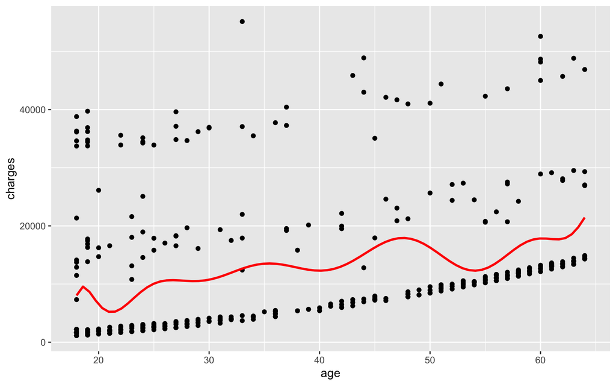

```r
insurance %>%
  ggplot(aes(x= age, y=charges)) +
  geom_point() +
  geom_smooth(method ='lm', formula=y ~ poly(x, 12), se = FALSE, color = 'Red')
```

## Part Four: New data

Great news! We’ve managed to collect data about the insurance costs for a few more individuals. You can find the new dataset here: https://www.dropbox.com/s/sky86agc4s8c6qe/insurance_costs_2.csv?dl=1

```r
insurance_new <- read_csv("https://www.dropbox.com/s/sky86agc4s8c6qe/insurance_costs_2.csv?dl=1")
```

1. For each model, fit the model on the original data.

-Only age as a predictor.

-age and bmi as a predictor.

-age, bmi, and smoker as predictors (no interaction terms)

-age, and bmi, with both quantitative variables having an interaction term with smoker (i.e. the formula ~ (age + bmi):smoker)

-age, bmi, and smokeras predictors, with both quantitative variables having an interaction term with smoker (i.e. the formula ~ (age + bmi)*smoker)

```r
lin_reg <- linear_reg() %>%
  set_mode("regression") %>%
  set_engine("lm")

modelA <- lin_reg %>%
  fit(charges ~ age, data = insurance)

modelB <- lin_reg %>%
  fit(charges ~ age + bmi, data = insurance)

modelC <- lin_reg %>%
  fit(charges ~ age + bmi + smoker, data = insurance)

modelD <- lin_reg %>%
  fit(charges ~ (age + bmi):smoker, data = insurance)

modelE <- lin_reg %>%
  fit(charges ~ (age + bmi)*smoker, data = insurance)
```

2. Then, use the fitted model to predict on the new data.

```r
insurance_new <- insurance_new %>%
  mutate(
    predA = predict(modelA, insurance_new)$.pred,
    predB = predict(modelB, insurance_new)$.pred,
    predC = predict(modelC, insurance_new)$.pred,
    predD = predict(modelD, insurance_new)$.pred,
    predE = predict(modelE, insurance_new)$.pred,
  )
```

```r
# MSE for modelA
mean((insurance_new$charges - insurance_new$predA)^2)
```

```
## [1] 136077137
```

```r
# MSE for modelB
mean((insurance_new$charges - insurance_new$predB)^2)
```

```
## [1] 132636406
```

```r
# MSE for modelC
mean((insurance_new$charges - insurance_new$predC)^2)
```

```
## [1] 35377541
```

```r
# MSE for modelD
mean((insurance_new$charges - insurance_new$predD)^2)
```

```
## [1] 24795908
```

```r
# MSE for modelE
mean((insurance_new$charges - insurance_new$predE)^2)
```

```
## [1] 21786257
```

-Report the MSE for each model’s new predictions. Based on this, which is the best model to use?

As seen above, modelE is the best model for making predictions since it has the lowest MSE value.

3. Use 5-fold cross-validation to compare the models above instead of the single train/test split method you used in the previous part. Are your conclusions the same?

```r
insurance_new_fold <- vfold_cv(insurance_new, v = 5)
insurance_new_fold
```

```
## #  5-fold cross-validation
## # A tibble: 5 × 2
##   splits           id
##   <list>           <chr>
## 1 <split [114/29]> Fold1
## 2 <split [114/29]> Fold2
## 3 <split [114/29]> Fold3
## 4 <split [115/28]> Fold4
## 5 <split [115/28]> Fold5
```

```r
modelA_cv <- lin_reg %>%
  fit_resamples(charges ~ age,
                resamples = insurance_new_fold)


modelB_cv <- lin_reg %>%
  fit_resamples(charges ~ age + bmi,
                resamples = insurance_new_fold)


modelC_cv <- lin_reg %>%
  fit_resamples(charges ~ age + bmi + smoker,
                resamples = insurance_new_fold)


modelD_cv <- lin_reg %>%
  fit_resamples(charges ~ (age + bmi):smoker,
                resamples = insurance_new_fold)


modelE_cv <- lin_reg %>%
  fit_resamples(charges ~ (age + bmi)*smoker,
                resamples = insurance_new_fold)
```

```r
modelA_cv %>% collect_metrics()
```

```
## # A tibble: 2 × 6
##   .metric .estimator      mean     n  std_err .config
##   <chr>   <chr>          <dbl> <int>    <dbl> <chr>
## 1 rmse    standard   11905.        5 699.     Preprocessor1_Model1
## 2 rsq     standard       0.172     5   0.0668 Preprocessor1_Model1
```

```r
modelB_cv %>% collect_metrics()
```

```
## # A tibble: 2 × 6
##   .metric .estimator      mean     n  std_err .config
##   <chr>   <chr>          <dbl> <int>    <dbl> <chr>
## 1 rmse    standard   12013.        5 627.     Preprocessor1_Model1
## 2 rsq     standard       0.133     5   0.0519 Preprocessor1_Model1
```

```r
modelC_cv %>% collect_metrics()
```

```
## # A tibble: 2 × 6
##   .metric .estimator     mean     n  std_err .config
##   <chr>   <chr>         <dbl> <int>    <dbl> <chr>
## 1 rmse    standard   6100.        5 266.     Preprocessor1_Model1
## 2 rsq     standard      0.792     5   0.0265 Preprocessor1_Model1
```

```r
modelD_cv %>% collect_metrics()
```

```
## # A tibble: 2 × 6
##   .metric .estimator     mean     n  std_err .config
##   <chr>   <chr>         <dbl> <int>    <dbl> <chr>
## 1 rmse    standard   4959.        5 409.     Preprocessor1_Model1
## 2 rsq     standard      0.851     5   0.0284 Preprocessor1_Model1
```

```r
modelE_cv %>% collect_metrics()
```

```
## # A tibble: 2 × 6
##   .metric .estimator     mean     n  std_err .config
##   <chr>   <chr>         <dbl> <int>    <dbl> <chr>
## 1 rmse    standard   4701.        5 559.     Preprocessor1_Model1
## 2 rsq     standard      0.870     5   0.0295 Preprocessor1_Model1
```

- The conclusion remains the same, the last model (ModelE_cv) is the best model for making predictions since it has the lowest RMSE and highest RSQ values.